# The very basics of R

https://github.com/sytspg/SalzbergSuSlay/

Josh Salzberg, Yitong Eric Su, and Sarah Slay

12/12/2025

# 1 Rationale and Research Questions

The goal of our analysis is to determine whether household income is correlated with specific climate change indicators. Due to redlining and disenfranchisement, low-income households tend to be located in areas more vulnerable to climate change. Determining whether household income is correlated with indicators such as flood risk or heat index informs policy initiatives. For example, flood damage costs exceeded $53 billion after hurricane Helene (Thomae, 2024). If flood risk increases with low-income households, these vulnerable populations would bear the highest cost. Policies for floodplain buyouts should aim to reduce cost burden for low-income households.

In addition, extreme heat exposure worsens chronic health conditions and can lead to premature death. Areas with lower socioeconomic status have limited access to resources such as health clinics that could address heatstroke symptoms (EPA, 2024). Therefore, if low-income households have a higher number of extreme heat days, they are more likely to suffer adverse effects. Level of walkability may also lead to worse health outcomes. People in less walkable areas have fewer opportunities to engage in physical exercise.

Lastly, we want to understand the distribution of climate change effects in NC. The varied topography and ecology of the state results in differing climate change impacts. Identifying counties with vulnerable populations will help decision-makers target policies to mitigate the effects of climate change.

We focused our analysis at the county level in North Carolina. Data was obtained for median household income and population distribution of each county, as well as climate change indicators. This data was wrangled and analyzed to answer the following questions:

1. Does average household income correlate with walkability, flood risk, and heat indices?
2. Are specific counties disproportionately at risk of climate change?

# 2 Dataset Information

We obtained data from the NC Data Portal (https://ncdataportal.org/), a platform that gathers social and environmental data related to North Carolina from government entities. By selecting specific parameters, we built a custom dataset.

*Table 1: Summary of Data*

| Variable Name | Variable Description |
| --- | --- |
| `County` | Name of North Carolina county |
| `Total.Population` | Count of county population |
| `TotalHouseholds` | Count of county households |
| `AvgHHinc` | County average household income |
| `MedHHinc` | County median household income |
| `WalkIndexScore` | County walkability score (based on EPA Walkability Index) |
| `LeastWalk` | Percent of population residing in area considered least walkable |
| `BelowAvgWalk` | Percent of population residing in area considered below average walkable |
| `AboveAvgWalk` | Percent of population residing in area considered above average walkable |
| `MostWalk` | Percent of population residing in area considered most walkable |
| `PopInFHA` | Count of county population residing in Flood Hazard Area |
| `PercentPopInFHA` | Percent of county population residing in Flood Hazard Area |
| `DailyMaxHeatIndex95Percentile` | Count of days per year maximum daily temperature exceeded 95th percentile, 2022-2024 |

## 2.1 Census USA counties shapefile

USA counties shapefile (cb_2018_us_county_20m.shp): this dataset provides mapping information for US counties and is filtered for to isolate the NC counties (FIPS: 37).

# 3 Exploratory Analysis

## 3.1 Data Wrangling & Summary

No columns were created in the data wrangling process, only removed or cleaned cleaned. Upon download, we inspected the data using functions `head()`, `str()`, `dim()`, and `colnames()`. Notably, `str()` revealed both far more columns than we needed, and that much data was stored as strings due to non-numeric characters within the data, principally `$`, `%`, and `,`. To resolve this, we subset the data into a new data frame, and used a combination of `lapply()` and `gsub()` code to remove the non-numeric characters in the data based on solutions from this [StackOverflow thread](https://stackoverflow.com/questions/74461334/replace-character-values-across-several-columns-at-once). With the `%` sign removed from the data, we applied a minor manipulation to convert the percentage columns into decimal form.

The table below communicates the findings from the `summary()` function applied to selected variables which gives us a brief understanding of the data dimensions.

|  | Total.Population | AvgHHinc | MedHHinc | WalkIndexScore | PopInFHA | PercentPopInFHA |
| --- | --- | --- | --- | --- | --- | --- |
|  | Min. : 3245 | Min. : 63045 | Min. : 51516 | Min. : 4.00 | Min. : 537 | Min. :0.02200 |
|  | 1st Qu.: 22566 | 1st Qu.: 83504 | 1st Qu.: 65719 | 1st Qu.: 5.00 | 1st Qu.: 1647 | 1st Qu.:0.03742 |
|  | Median : 51352 | Median : 93719 | Median : 74568 | Median : 6.00 | Median : 3293 | Median :0.05075 |
|  | Mean : 104394 | Mean : 97676 | Mean : 77228 | Mean : 5.94 | Mean : 5869 | Mean :0.09853 |
|  | 3rd Qu.: 116343 | 3rd Qu.:105823 | 3rd Qu.: 82938 | 3rd Qu.: 6.00 | 3rd Qu.: 6980 | 3rd Qu.:0.10615 |
|  | Max. :1129410 | Max. :177194 | Max. :128556 | Max. :11.00 | Max. :43070 | Max. :0.94470 |

## 3.2 Data Distribution

Our exploratory analysis indicates that population count is right skewed because the mean is larger than the median. The graph, figure 1A below, provides visual proof. We identified two outlier counties with populations over 1 million as Wake and Mecklenburg Counties. The significant range in county population has implications for our analysis.

Figure 1B shows that household income does not demonstrate the same absolute magnitude in range. However, average household income exhibits rightward skew due to the highest income households bringing averages up. For median household income, the range is much smaller, and is less influenced by the largest incomes in each county. Capturing this difference helps us understand the extent of income ranges between and within counties.

Figure 1C demonstrates that approximately three quarters of counties in North Carolina have fewer than 10% of their population inhabiting Flood Hazard Areas. However, there are three counties with over 50% of their population residing in Flood Hazard Areas. The highest rate shown is nearly 95% of residents. To accommodate such a dramatic skew in our analysis, we apply a log transformation to normalize the distribution.

Lastly, in Figure 1D, we explore how the number of days over the county’s 95th percentile Heat Index is distributed across the state. We can see that the data approximates a normal distribution, but further analysis would be required to confirm the goodness of fit, especially given the slightly off-center mode.

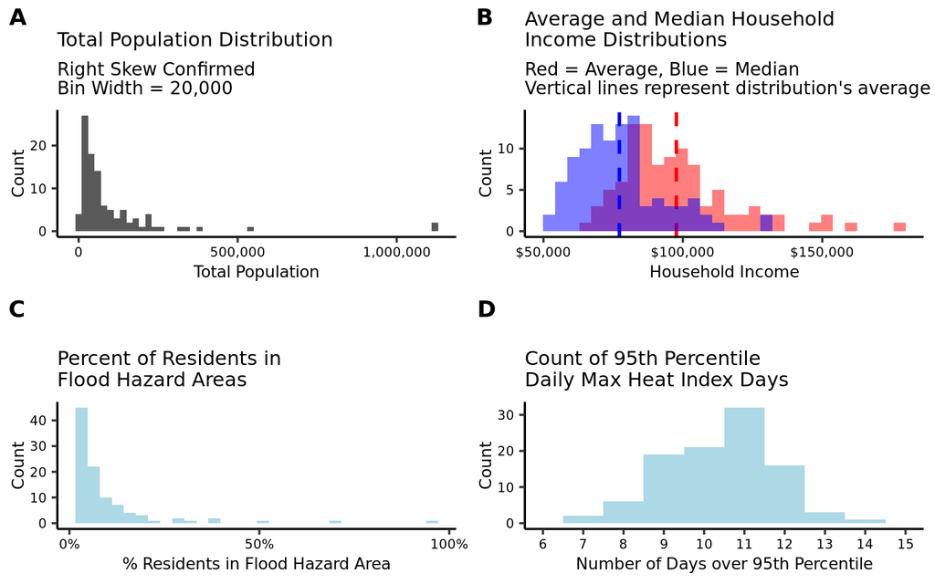

*Fig 1. Exploratory Analysis of Parameters*

Figure 2 demonstrates the percentage of residents in different designations of walkability. Level of walkability across the state is low. It appears a significant proportion of counties have well over half their population residing in “least walkable” and “below average walkable” conditions (plots A & B below). These two walkability designations approach normal distributions. Plots C & D, “above average walkable” and “most walkable,” respectively, approach exponential distributions, with the majority of counties containing 0% of residents in the given walkability designation.

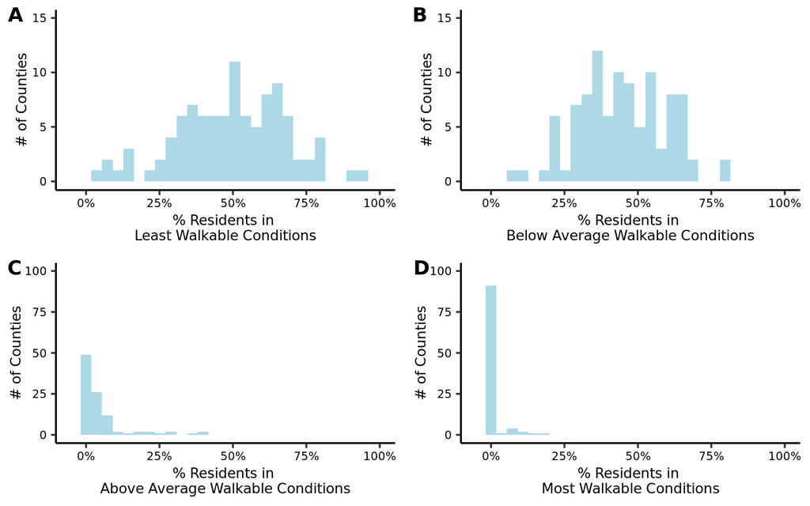

*Fig 2. Distribution of the Walkability-related Indices*

## 3.3 Question 1: Does average household income correlate with walkability, flood risk, and heat indices?

*H0:* There is no significant difference between walkability, flood risk, and heat index based on household income.

*HA:* There is a significant difference between walkability, flood risk, and heat index based on household income.

## 3.4 Question 2: Are specific counties disproportionately at risk of climate change?

*H0:* There is no significant difference in climate risk between counties.

*HA:* There is a significant difference in climate risk between counties.

Prior to analysis, we predict that counties closer to the coast are more at risk of climate change. These areas are subject to shifting coastlines, flooding, and hurricanes that will intensify with climate change.

# 4 Analyses

## 4.1 Regression

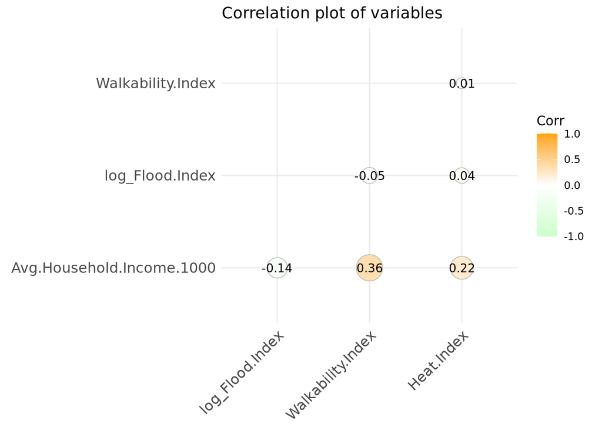

*Fig 3. Correlation plot of the indices*

### 4.1.1 Correlation Plot

The correlation plot (Figure 3) shows that walkability has the highest correlation with average income at 0.36. Heat index is also correlated with average income at 0.22. Both correlations are positive, meaning that walkability and high heat days increase with average income. Conversely, flooding is negatively correlated with avearge household income. None of the correlations are particularly strong across all NC counties. It should be noted that the correlation plot does not evaluate statistical significance of these relationships.

### 4.1.2 Regression 1: Heat Index ~ Average Household Income

This regression modeled the relationship between average household income and heat index. According to the regression, average income is positively correlated with heat index. The p-value for the coefficient was statistically significant (p = 0.0257 < 0.05) but the R-squared value was only 0.0497, indicating a weak relationship.

### 4.1.3 Regression 2: Walkability Index ~ Average Household Income

This regression assessed correlation between average household income and walkability. These variables are slightly positively correlated and the correlation is statistically significant (p = 0.0003 << 0.05). The increase in walkability with household income is a stronger relationship than heat index with an R-squared value of 0.1175.

### 4.1.4 Regression 3: Flood Index ~ Average Household Income

This regression examined the relationship between average household income and flood hazard area. These variables show no statistically significant correlation (p = 0.1567), but the R-squared value only explained ~2% of the relationship.

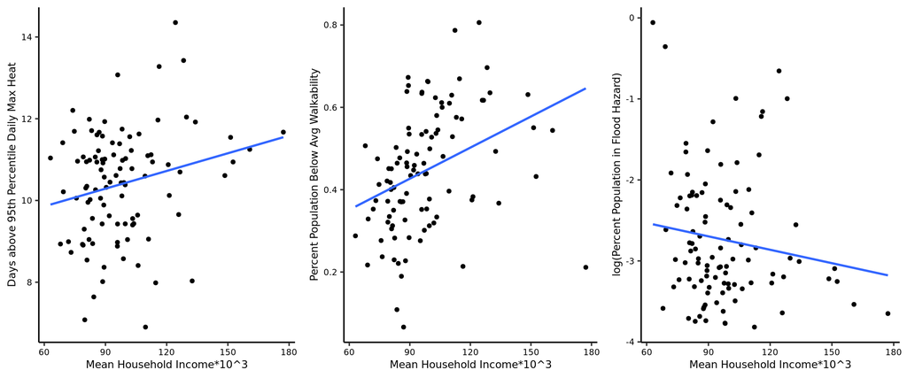

*Fig 4. Scatterplot showing the three relationships mentioned above, with linear regression line applied*

### 4.1.5 Regression Plots

These plots visualize the regressions performed for the three climate change indicators and average household income.

## 4.2 Spatial Analysis

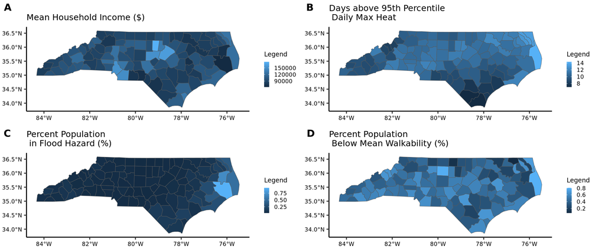

*Fig 5. NC county maps showing the spatial distribution of the indices*

## 4.3 NC County Maps

# 5 Summary and Conclusions

Our analysis indicates that walkability and high heat index days/yr increase slightly with average household income. These relationships were statistically significant at a p = 0.05 level. Therefore, we can partially reject the null hypothesis for research question one. The rejection is partial because percent population in flood hazard areas does not depend on average income at the county level. These findings contradict our initial assumption that low-income areas would have lower walkability and more heat days.

In conclusion, decision-makers should consider these climate change indicators when designing policies. Targeted policies for high-risk counties would save costs and have more effective outcomes. However, further research is required beyond the county level. Although household income did not correlate with flood hazard in our analysis, a relationship may appear if the analysis was conducted within counties or regionally.

# 6 References

Environmental Protection Agency. (2024). Climate Change and the Health of Socially Vulnerable People. EPA. https://www.epa.gov/climateimpacts/climate-change-and-health-socially-vulnerable-people

Thomae, L. (2024, December 3). Helene damage costs in NC more than $53 billion. who will pay is unclear. Carolina Public Press. https://carolinapublicpress.org/67325/helene-costs-nc-billions-unclear-who-pays/